# day1_SCHMITZ.R

laura

2025-11-20

**The Basics**

**Installing/Loading packages**

```r
require(tidyverse)
```

```r
require(pheatmap)
```

**Variables**

We now assign values to variables **a** and **b**

```r
a <- 1
b <- 3
```

And ask R which kind of key data our new variables are, i.e. a **character** (=words), a **boolean** (= true or false), or a **double** (= a number):

```r
typeof(a)
```

```
## [1] "double"
```

```r
typeof(b)
```

```
## [1] "double"
```

We can also ask for the data structure or just ask R to give the values correspondent to each variable

```r
str(a)
```

```
##  num 1
```

```r
str(b)
```

```
##  num 3
```

```r
a # = <code>print(a)</code>
```

```
## [1] 1
```

```r
b # = <code>print(b)</code>
```

```
## [1] 3
```

**Functions**

We can apply a **sum** function to our variables in different ways:

```r
sum(a,b)
```

```
## [1] 4
```

```r
a + b
```

```
## [1] 4
```

```r
sum(5,6)
```

```
## [1] 11
```

Results from functions can be stored in new variables:

```r
c <- sum(a,b)
(c <- sum(a,b))
```

```
## [1] 4
```

We can then check the value for the new variable or use it for more functions

```r
str(c)
```

```
##  num 4
```

```r
sum(a,c)
```

```
## [1] 5
```

Importantly, the sum function cannot be applied to characters.

```r
a <- "abc"
b <- "hello"
sum(a,b)
```

```
## Error in sum(a, b): invalid 'type' (character) of argument
```

```r
typeof(a)
```

```
## [1] "character"
```

```r
typeof(b)
```

```
## [1] "character"
```

```r
str(a)
```

```
##  chr "abc"
```

```r
str(b)
```

```
##  chr "hello"
```

We can transform them into **booleans**:

```r
a <- TRUE
b <- FALSE
sum(a,b)
```

```
## [1] 1
```

```r
sum(a,a)
```

```
## [1] 2
```

```r
typeof(a)
```

```
## [1] "logical"
```

```r
typeof(b)
```

```
## [1] "logical"
```

```r
str(a)
```

```
##  logi TRUE
```

```r
str(b)
```

```
##  logi FALSE
```

**Vectors**

We create a vector by creating a collection of individual values of only one type:

```r
vec <- c(1,2,3,4,1,2,3)
```

For instance, we can say that the values 1, 2, 3, and 4 correspond to the first 4 letters of the alphabet by **assigning names**:

```r
names(vec) <- LETTERS[1:4]
str(vec)
```

```
##  Named num [1:7] 1 2 3 4 1 2 3
##  - attr(*, "names")= chr [1:7] "A" "B" "C" "D" ...
```

Even if we assigned characters to our values, R can still read them as numbers:

```r
sum(vec)
```

```
## [1] 16
```

```r
mean(vec)
```

```
## [1] 2.285714
```

```r
vec[2]
```

```
## B
## 2
```

```r
vec[3]
```

```
## C
## 3
```

```r
vec["A"]
```

```
## A
## 1
```

```r
vec[c("A", "D")]
```

```
## A D
## 1 4
```

The `unique` function returns the non-duplicate values in our vector

```r
unique(vec)
```

```
## [1] 1 2 3 4
```

With **X:Z** we can ask for values ranging from value “X” to value “Z”

```r
1:10
```

```
##  [1]  1  2  3  4  5  6  7  8  9 10
```

```r
-5:5
```

```
##  [1] -5 -4 -3 -2 -1  0  1  2  3  4  5
```

```r
vec <- 10:1
vec[2:3]
```

```
## [1] 9 8
```

Finally, we can create a vector of the letters **B,C,D**. The stopifnot() statement will test if this worked correctly.

```r
your.vector <- LETTERS[2:4]
stopifnot(your.vector == c("B", "C", "D"))
str(your.vector)
```

```
##  chr [1:3] "B" "C" "D"
```

**Lists**

```r
list_x <- list("a", 1, "b", "xyz", TRUE)
str(list_x)
```

```
## List of 5
##  $ : chr "a"
##  $ : num 1
##  $ : chr "b"
##  $ : chr "xyz"
##  $ : logi TRUE
```

```r
list_x[[1]]
```

```
## [1] "a"
```

```r
str(list_x[[1]])
```

```
##  chr "a"
```

```r
str(list_x[1])
```

```
## List of 1
##  $ : chr "a"
```

```r
list_x[[2]]
```

```
## [1] 1
```

```r
list_x[2:4]
```

```
## [[1]]
## [1] 1
##
## [[2]]
## [1] "b"
##
## [[3]]
## [1] "xyz"
```

```r
str(list_x[2:4])
```

```
## List of 3
##  $ : num 1
##  $ : chr "b"
##  $ : chr "xyz"
```

```r
vec_x <- c("a", 1, "b", "xyz", TRUE)
```

Now R has converted all non-characters to characters:

```r
str(vec_x)
```

```
##  chr [1:5] "a" "1" "b" "xyz" "TRUE"
```

**Loops and Conditions**

```r
for(x in 1:6){
  print(paste("x =", x))
  if(x > 3){
    print("...x is greater than three")
  }
  if(x == 2){
    print("...x equals two")
  }
  if(x != 4){
    print("...x is not four")
  }
  if(x %% 2 == 0){
    print("...x is even")
  } else {
    print("...x is uneven")
  }
  if(x %in% c(3,5)){
    print("...x is three or five")
  }
  print("-------")
}
```

```
## [1] "x = 1"
## [1] "...x is not four"
## [1] "...x is uneven"
## [1] "-------"
## [1] "x = 2"
## [1] "...x equals two"
## [1] "...x is not four"
## [1] "...x is even"
## [1] "-------"
## [1] "x = 3"
## [1] "...x is not four"
## [1] "...x is uneven"
## [1] "...x is three or five"
## [1] "-------"
## [1] "x = 4"
## [1] "...x is greater than three"
## [1] "...x is even"
## [1] "-------"
## [1] "x = 5"
## [1] "...x is greater than three"
## [1] "...x is not four"
## [1] "...x is uneven"
## [1] "...x is three or five"
## [1] "-------"
## [1] "x = 6"
## [1] "...x is greater than three"
## [1] "...x is not four"
## [1] "...x is even"
## [1] "-------"
```

**Matrices**

**`Downloading data.RDF`**

```r
setwd("G:/My Drive/. PLUS/. MASTER Medical Biology/ALL COURSES/UE Hands-on Biomedical Data – Resources and Analysis Tools (4.5 ECTS)/Teil Fortelny")
m <- readRDS("data.RDS")
```

**1.1) Subset the matrix to the first 30 rows and the first 10 columns. The stopifnot() statement will test if this worked correctly.**

```r
matrix.check <- m[1:30,1:10] # = m[rows X until Z, columns X until Z]
dim(matrix.check)
```

```
## [1] 30 10
```

```r
stopifnot(all(dim(matrix.check) == c(30,10)))
```

**`Subsetting to Liver_Fibroblasts only`**

Now we get all columns that match the string `“Liver_Fibroblasts”`

```r
grepl("Liver_Fibroblasts", colnames(m)) # searches for the pattern "Liver_Fibroblasts" in all column names of the matrix "m")
```

```
##   [1]  TRUE  TRUE FALSE FALSE FALSE FALSE  TRUE FALSE FALSE FALSE FALSE FALSE
##  [13] FALSE FALSE FALSE FALSE  TRUE FALSE FALSE FALSE FALSE FALSE FALSE FALSE
##  [25] FALSE FALSE FALSE FALSE FALSE FALSE FALSE FALSE FALSE FALSE FALSE FALSE
##  [37] FALSE FALSE FALSE FALSE FALSE FALSE FALSE FALSE  TRUE FALSE FALSE FALSE
##  [49] FALSE FALSE FALSE FALSE FALSE FALSE FALSE FALSE FALSE FALSE FALSE FALSE
##  [61]  TRUE  TRUE FALSE FALSE FALSE FALSE FALSE FALSE FALSE FALSE FALSE FALSE
##  [73] FALSE FALSE  TRUE FALSE FALSE  TRUE FALSE FALSE FALSE FALSE FALSE FALSE
##  [85] FALSE FALSE FALSE FALSE FALSE FALSE FALSE FALSE FALSE FALSE FALSE FALSE
##  [97] FALSE FALSE FALSE FALSE FALSE FALSE FALSE FALSE FALSE FALSE FALSE FALSE
## [109] FALSE FALSE FALSE FALSE FALSE FALSE FALSE FALSE FALSE FALSE FALSE  TRUE
## [121] FALSE FALSE FALSE FALSE FALSE FALSE FALSE FALSE FALSE  TRUE  TRUE FALSE
## [133] FALSE FALSE FALSE FALSE FALSE  TRUE FALSE FALSE FALSE FALSE FALSE FALSE
## [145] FALSE FALSE FALSE FALSE  TRUE FALSE  TRUE FALSE FALSE FALSE FALSE  TRUE
## [157] FALSE FALSE FALSE FALSE FALSE FALSE FALSE FALSE FALSE FALSE FALSE FALSE
## [169] FALSE FALSE FALSE FALSE FALSE FALSE FALSE FALSE FALSE FALSE FALSE FALSE
## [181] FALSE FALSE FALSE FALSE FALSE FALSE FALSE FALSE FALSE FALSE FALSE FALSE
## [193] FALSE FALSE FALSE FALSE FALSE FALSE FALSE FALSE FALSE  TRUE FALSE FALSE
## [205] FALSE FALSE FALSE FALSE FALSE FALSE FALSE FALSE FALSE FALSE FALSE FALSE
## [217] FALSE FALSE FALSE FALSE FALSE FALSE FALSE FALSE FALSE FALSE  TRUE  TRUE
## [229]  TRUE FALSE
```

```r
dim(m) # this yields 22055 rows and 230 columns
```

```
## [1] 22055   230
```

```r
dim(m[, grepl("Liver_Fibroblasts", colnames(m))]) # when filtering by "Liver_Fibroblasts", we have only 20 columns
```

```
## [1] 22055    20
```

We can now subset the matrix by getting only the first 20 rows of `“Liver_Fibroblasts”` string

```r
matrix2plot <- m[1:20, grepl("Liver_Fibroblasts", colnames(m))]
```

And rename the columns and rows of this new subset

```r
colnames(matrix2plot) <- gsub("^Liver_Fibroblasts_(.+)_RNA_(\\d)$", "\\1_\\2", colnames(matrix2plot)) #deletes "Liver_Fibroblasts" and "RNA" from all column names of the new subset
row.names(matrix2plot) <- paste0("g", 1:nrow(matrix2plot)) #replaces the gene name by "g" + number of the row in this new subset
str(matrix2plot)
```

```
##  num [1:20, 1:20] 1668 0 0 0 0 ...
##  - attr(*, "dimnames")=List of 2
##   ..$ : chr [1:20] "g1" "g2" "g3" "g4" ...
##   ..$ : chr [1:20] "IL6_2" "TGFb_3" "TNF_1" "IFNa_2" ...
```

```r
matrix2plot
```

```
##     IL6_2 TGFb_3 TNF_1 IFNa_2 PBS_1 IFNa_3 TGFb_1 IL3_1 IL3_3 IL6_1 PBS_3 IL3_2
## g1   1668    111     6      3  1981   7024     11     4  6775    13   302  1614
## g2      0      0     0      0     0      0      0     0     0     0     0     0
## g3      0      2   224      0     0      0      0     0  1956     0     1     0
## g4      0      0     0      0     0      0      0     0     0     0     1     0
## g5      0   1639     0   7602  3222  17104   1509    40  1311  1238  1579  3643
## g6    712      0     0      0     1      0      1     1     0     2     0   589
## g7     12      5     0      1    15      3      5     0     7   930  4400     3
## g8   1495     15  1392  12620  4074     21     37    60  2619 19716    14   433
## g9      0      4     4      0    29      0      2     0   530     0     1     1
## g10  1409    589  2331   5359   835   1923    799     3  2816  1617     1   593
## g11    22      0     0      0     1      0      0     0     0     1     0     0
## g12     0      0     0      0     0      0      0     0     0     0     0     0
## g13     0      0     0      0     0      0      0     0     0     0     0     0
## g14     3      0     0      0     1      0      0     0     0     0     0     0
## g15     0      0     0      6     0      0      0     0     0     0     0     0
## g16     0      0     0      0     0      0      0     0     0     0    14     0
## g17     1      8     1    382     2     99      2     1     1     1     2  1854
## g18  1183      0     9     39     3    143      1     1     3  1478    44     1
## g19  2845   2327    14      0   656    112      1     0  1021  3058   152     0
## g20     2      0     1      0     0      0      0     0     0   387     1     3
##     IL6_3 IFNa_1 TGFb_2 TNF_2 PBS_2 IFNg_2 IFNg_3 IFNg_1
## g1    418      7   3034    28     2      1     32      0
## g2      0      0      0     0     0      0      0      0
## g3      1      0      0     0     0      0      0      0
## g4      0      0      1     0     0      0      0      0
## g5    622      6   3966  5084    60      0      0   2424
## g6      0      1     96     1     0      0      0      0
## g7     82      5      5    12     8      0      0      1
## g8   2792     48     16    58     9      1    403   1332
## g9      1      0     10     3     0      0    169    140
## g10   808   3141      2   289     5   4764   1786    518
## g11   296      0      0     0     1      0      0      0
## g12     0      0      0     0     0      0      0      0
## g13     0      0      0     0     0      0      0      0
## g14     0      0    769  2267     1      0      0      0
## g15     0      0      0     0     0      0      0      0
## g16     0      0      0     0     0      0      0      0
## g17     1      3      1     5     1      0    344    548
## g18     2      4     41  3055    33      0     44      2
## g19    15      0     29     3     1      3   1764     62
## g20     1      0      3     0    49      0      0      0
```

Now we switch rows and columns using the `t` function:

```r
t(matrix2plot)
```

```
##          g1 g2   g3 g4    g5  g6   g7    g8  g9  g10 g11 g12 g13  g14 g15 g16
## IL6_2  1668  0    0  0     0 712   12  1495   0 1409  22   0   0    3   0   0
## TGFb_3  111  0    2  0  1639   0    5    15   4  589   0   0   0    0   0   0
## TNF_1     6  0  224  0     0   0    0  1392   4 2331   0   0   0    0   0   0
## IFNa_2    3  0    0  0  7602   0    1 12620   0 5359   0   0   0    0   6   0
## PBS_1  1981  0    0  0  3222   1   15  4074  29  835   1   0   0    1   0   0
## IFNa_3 7024  0    0  0 17104   0    3    21   0 1923   0   0   0    0   0   0
## TGFb_1   11  0    0  0  1509   1    5    37   2  799   0   0   0    0   0   0
## IL3_1     4  0    0  0    40   1    0    60   0    3   0   0   0    0   0   0
## IL3_3  6775  0 1956  0  1311   0    7  2619 530 2816   0   0   0    0   0   0
## IL6_1    13  0    0  0  1238   2  930 19716   0 1617   1   0   0    0   0   0
## PBS_3   302  0    1  1  1579   0 4400    14   1    1   0   0   0    0   0  14
## IL3_2  1614  0    0  0  3643 589    3   433   1  593   0   0   0    0   0   0
## IL6_3   418  0    1  0   622   0   82  2792   1  808 296   0   0    0   0   0
## IFNa_1    7  0    0  0     6   1    5    48   0 3141   0   0   0    0   0   0
## TGFb_2 3034  0    0  1  3966  96    5    16  10    2   0   0   0  769   0   0
## TNF_2    28  0    0  0  5084   1   12    58   3  289   0   0   0 2267   0   0
## PBS_2     2  0    0  0    60   0    8     9   0    5   1   0   0    1   0   0
## IFNg_2    1  0    0  0     0   0    0     1   0 4764   0   0   0    0   0   0
## IFNg_3   32  0    0  0     0   0    0   403 169 1786   0   0   0    0   0   0
## IFNg_1    0  0    0  0  2424   0    1  1332 140  518   0   0   0    0   0   0
##         g17  g18  g19 g20
## IL6_2     1 1183 2845   2
## TGFb_3    8    0 2327   0
## TNF_1     1    9   14   1
## IFNa_2  382   39    0   0
## PBS_1     2    3  656   0
## IFNa_3   99  143  112   0
## TGFb_1    2    1    1   0
## IL3_1     1    1    0   0
## IL3_3     1    3 1021   0
## IL6_1     1 1478 3058 387
## PBS_3     2   44  152   1
## IL3_2  1854    1    0   3
## IL6_3     1    2   15   1
## IFNa_1    3    4    0   0
## TGFb_2    1   41   29   3
## TNF_2     5 3055    3   0
## PBS_2     1   33    1  49
## IFNg_2    0    0    3   0
## IFNg_3  344   44 1764   0
## IFNg_1  548    2   62   0
```

```r
dim(matrix2plot) # before transposing
```

```
## [1] 20 20
```

```r
dim(t(matrix2plot)) # after transposing
```

```
## [1] 20 20
```

**Calculate Spearman correlation**

```r
cMT_before <- cor(matrix2plot, method="spearman")
head(cMT_before)
```

```
##            IL6_2    TGFb_3     TNF_1    IFNa_2     PBS_1    IFNa_3    TGFb_1
## IL6_2  1.0000000 0.4348869 0.5429904 0.3336479 0.6574785 0.5747640 0.5039096
## TGFb_3 0.4348869 1.0000000 0.5993691 0.5657252 0.8176152 0.7942448 0.8301574
## TNF_1  0.5429904 0.5993691 1.0000000 0.3852197 0.5150741 0.5125420 0.4796276
## IFNa_2 0.3336479 0.5657252 0.3852197 1.0000000 0.6617169 0.7801724 0.7560388
## PBS_1  0.6574785 0.8176152 0.5150741 0.6617169 1.0000000 0.8228649 0.9256020
## IFNa_3 0.5747640 0.7942448 0.5125420 0.7801724 0.8228649 1.0000000 0.8419110
##            IL3_1     IL3_3     IL6_1     PBS_3     IL3_2     IL6_3    IFNa_1
## IL6_2  0.4930959 0.4699791 0.7953701 0.3662759 0.3995727 0.6214578 0.5649770
## TGFb_3 0.5496666 0.8864129 0.6344723 0.6953074 0.5923300 0.7700799 0.6196038
## TNF_1  0.4356716 0.7799199 0.5566010 0.4105859 0.3429666 0.6226622 0.4251822
## IFNa_2 0.8042615 0.6025343 0.6163911 0.5171648 0.7010652 0.6523170 0.8481801
## PBS_1  0.7337127 0.7926782 0.7679195 0.6384832 0.6972578 0.8369677 0.7807117
## IFNa_3 0.7663434 0.7725496 0.7855093 0.7611022 0.6992501 0.7751217 0.8223180
##           TGFb_2     TNF_2     PBS_2    IFNg_2    IFNg_3    IFNg_1
## IL6_2  0.5648214 0.5398926 0.5742788 0.7188270 0.6104677 0.2989485
## TGFb_3 0.4736229 0.5947639 0.4791517 0.6927770 0.6740706 0.7570871
## TNF_1  0.2554340 0.3825822 0.3757792 0.6942680 0.8154327 0.4995310
## IFNa_2 0.3638878 0.6844834 0.6347800 0.3917934 0.5008748 0.7136015
## PBS_1  0.7408117 0.8478941 0.6552976 0.6359939 0.6993256 0.7903718
## IFNa_3 0.6041665 0.7890697 0.7236760 0.6122911 0.6422748 0.7207854
```

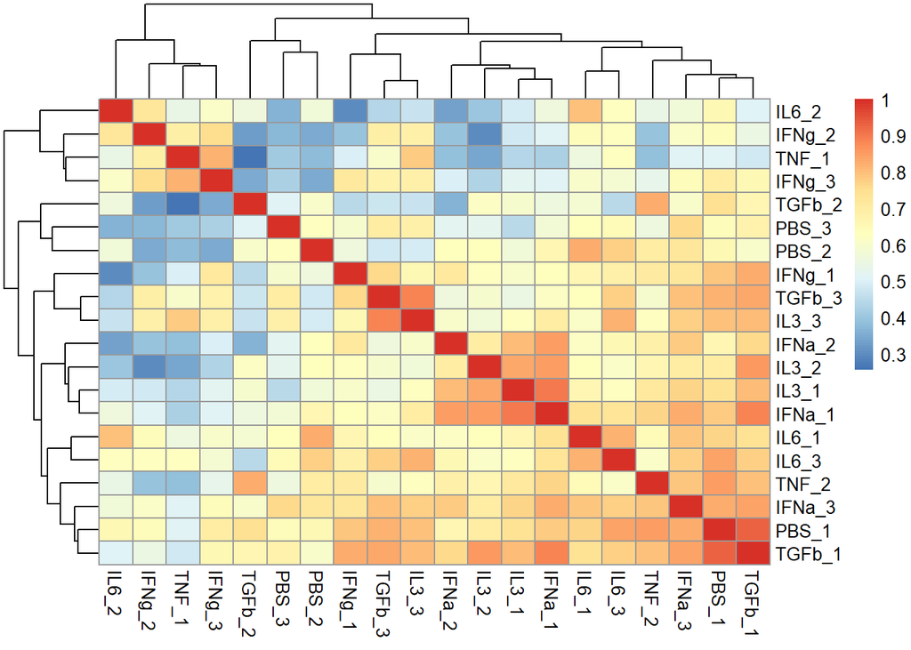

```r
pheatmap(cMT_before)
```

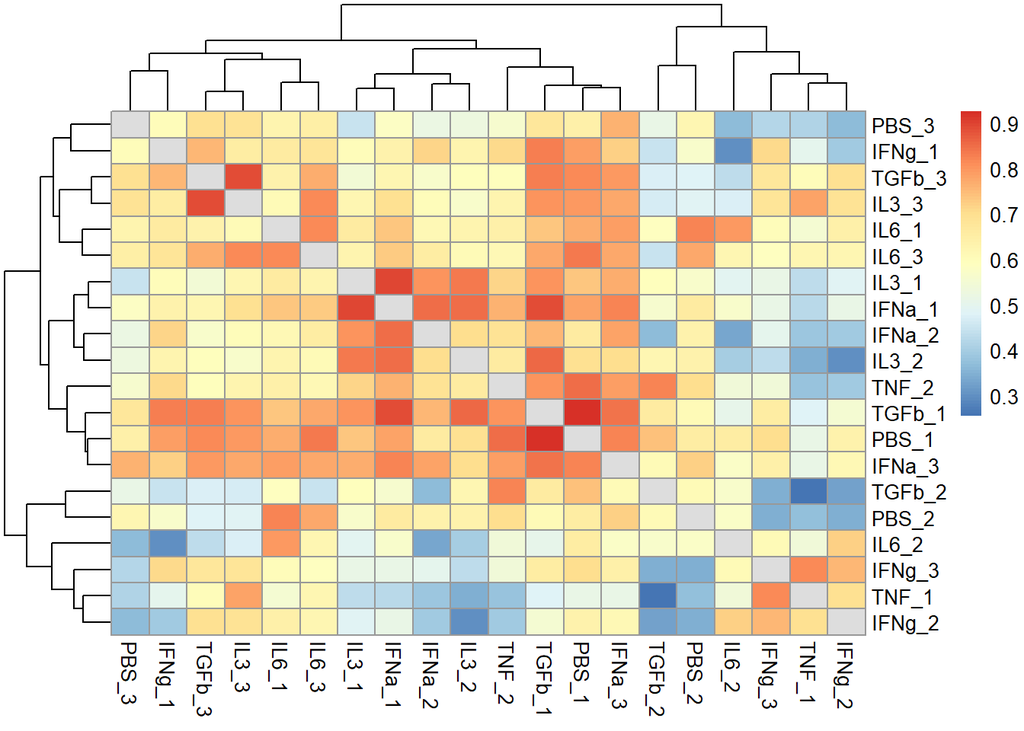

```r
cMT_after <- cor(matrix2plot, method="spearman")
diag(cMT_after) <- NA  # removes the diagonal "1"s from the heatmap - they are uninformative
pheatmap(cMT_after)
```

**Data Frames and dplyr**

**`Loading the starwars subset`**

```r
starwars
```

```
## # A tibble: 87 × 14
##    name     height  mass hair_color skin_color eye_color birth_year sex   gender
##    <chr>     <int> <dbl> <chr>      <chr>      <chr>          <dbl> <chr> <chr>
##  1 Luke Sk…    172    77 blond      fair       blue            19   male  mascu…
##  2 C-3PO       167    75 <NA>       gold       yellow         112   none  mascu…
##  3 R2-D2        96    32 <NA>       white, bl… red             33   none  mascu…
##  4 Darth V…    202   136 none       white      yellow          41.9 male  mascu…
##  5 Leia Or…    150    49 brown      light      brown           19   fema… femin…
##  6 Owen La…    178   120 brown, gr… light      blue            52   male  mascu…
##  7 Beru Wh…    165    75 brown      light      blue            47   fema… femin…
##  8 R5-D4        97    32 <NA>       white, red red             NA   none  mascu…
##  9 Biggs D…    183    84 black      light      brown           24   male  mascu…
## 10 Obi-Wan…    182    77 auburn, w… fair       blue-gray       57   male  mascu…
## # ℹ 77 more rows
## # ℹ 5 more variables: homeworld <chr>, species <chr>, films <list>,
## #   vehicles <list>, starships <list>
```

```r
str(starwars$name)
```

```
##  chr [1:87] "Luke Skywalker" "C-3PO" "R2-D2" "Darth Vader" "Leia Organa" ...
```

```r
stopifnot(length(unique(starwars$name))==nrow(starwars))
```

We only keep columns that are not of the type `list` and convert the table to a **data frame**:

```r
sw <- starwars |>
  select(where(function(x) !is.list(x))) |>
  as.data.frame()
```

To count the number of rows corresponding to each variable “homeworld”

```r
sw |> count(homeworld)
```

```
##         homeworld  n
## 1        Alderaan  3
## 2     Aleen Minor  1
## 3          Bespin  1
## 4      Bestine IV  1
## 5  Cato Neimoidia  1
## 6           Cerea  1
## 7        Champala  1
## 8       Chandrila  1
## 9    Concord Dawn  1
## 10       Corellia  2
## 11      Coruscant  3
## 12       Dathomir  1
## 13          Dorin  1
## 14          Endor  1
```

[output cut: 35 more lines]

To extract the first name from the first column and add it to a new column called “first name”

```r
sw <- sw |>
  mutate(firstname = str_remove(name, " .+$"))
```

**1.2) Assess the gender balance of this table, using count() and gender. Report the code and result in your protocol.**

```r
sw |> count(sex)
```

```
##              sex  n
## 1         female 16
## 2 hermaphroditic  1
## 3           male 60
## 4           none  6
## 5           <NA>  4
```

**1.3) Count the number of characters by their skin_color and then run a given code What is the difference between the two approaches to count by skin color?**

**Counting characters by `skin_color` using `count()`** This counts characters by skin color combination - characters with only blue + white skin will be counted separately than those with blue skin or white skin only.

```r
sw |> count(skin_color)
```

```
##             skin_color  n
## 1                 blue  2
## 2           blue, grey  2
## 3                brown  4
## 4         brown mottle  1
## 5         brown, white  1
## 6                 dark  6
## 7                 fair 17
## 8  fair, green, yellow  1
## 9                 gold  1
## 10               green  6
## 11         green, grey  1
## 12    green-tan, brown  1
## 13                grey  6
## 14          grey, blue  1
```

[output cut: 17 more lines]

**Running the provided code with more functions** This will disregard color combinations and count the amount of characters with each skin color

```r
sw |>
  pull("skin_color") |> # gets "skin_color" variables
  str_split(", ") |> # splits variables separated by a comma
  unlist() |> # flattens all variables into a vector
  table() |> # combines it again into a table
  sort() # sort the elements from the vector alphabetically and gives the amount of characters (rows) per variable
```

```
##
##  brown mottle          gold     green-tan         metal mottled green
##             1             1             1             1             1
##        silver       unknown          none        orange           tan
##             1             1             2             2             2
##        yellow          pale           red         brown          dark
##             4             5             5             6             6
##         white          blue         green         light          grey
##             7             8             9            11            12
##          fair
##            18
```

**1.4) Who is taller than 2m?**

```r
sw |>
  filter(height > 200) |>
  pull(name)
```

```
##  [1] "Darth Vader"  "Chewbacca"    "Roos Tarpals" "Rugor Nass"   "Yarael Poof"
##  [6] "Lama Su"      "Taun We"      "Grievous"     "Tarfful"      "Tion Medon"
```

**1.5) Now let’s take a detailed look at filters and conditions. What is the difference between these 3 approaches?**

**Approach 1:**

```r
 starwars |>
   filter(hair_color == "blond") |>
   filter(sex == "male")
```

```
## # A tibble: 3 × 14
##   name      height  mass hair_color skin_color eye_color birth_year sex   gender
##   <chr>      <int> <dbl> <chr>      <chr>      <chr>          <dbl> <chr> <chr>
## 1 Luke Sky…    172    77 blond      fair       blue            19   male  mascu…
## 2 Anakin S…    188    84 blond      fair       blue            41.9 male  mascu…
## 3 Finis Va…    170    NA blond      fair       blue            91   male  mascu…
## # ℹ 5 more variables: homeworld <chr>, species <chr>, films <list>,
## #   vehicles <list>, starships <list>
```

**Approach 2:**

```r
 starwars |>
   filter(hair_color == "blond" & sex == "male")
```

```
## # A tibble: 3 × 14
##   name      height  mass hair_color skin_color eye_color birth_year sex   gender
##   <chr>      <int> <dbl> <chr>      <chr>      <chr>          <dbl> <chr> <chr>
## 1 Luke Sky…    172    77 blond      fair       blue            19   male  mascu…
## 2 Anakin S…    188    84 blond      fair       blue            41.9 male  mascu…
## 3 Finis Va…    170    NA blond      fair       blue            91   male  mascu…
## # ℹ 5 more variables: homeworld <chr>, species <chr>, films <list>,
## #   vehicles <list>, starships <list>
```

**Approach 3:**

```r
 starwars |>
   filter(hair_color == "blond" | sex == "male")
```

```
## # A tibble: 60 × 14
##    name     height  mass hair_color skin_color eye_color birth_year sex   gender
##    <chr>     <int> <dbl> <chr>      <chr>      <chr>          <dbl> <chr> <chr>
##  1 Luke Sk…    172    77 blond      fair       blue            19   male  mascu…
##  2 Darth V…    202   136 none       white      yellow          41.9 male  mascu…
##  3 Owen La…    178   120 brown, gr… light      blue            52   male  mascu…
##  4 Biggs D…    183    84 black      light      brown           24   male  mascu…
##  5 Obi-Wan…    182    77 auburn, w… fair       blue-gray       57   male  mascu…
##  6 Anakin …    188    84 blond      fair       blue            41.9 male  mascu…
##  7 Wilhuff…    180    NA auburn, g… fair       blue            64   male  mascu…
##  8 Chewbac…    228   112 brown      unknown    blue           200   male  mascu…
##  9 Han Solo    180    80 brown      fair       brown           29   male  mascu…
## 10 Greedo      173    74 <NA>       green      black           44   male  mascu…
## # ℹ 50 more rows
## # ℹ 5 more variables: homeworld <chr>, species <chr>, films <list>,
## #   vehicles <list>, starships <list>
```

**Calculating BMI (`mass/(height/100)^2`) for all characters:**

```r
sw <- sw %>%
  mutate(bmi = mass / (height/100)^2)
```

**Visualizing distribution of BMI:**

```r
quantile(sw$bmi, na.rm = TRUE) # Using the $ operator
```

```
##        0%       25%       50%       75%      100%
##  12.88625  21.51109  24.67038  26.60305 443.42857
```

```r
quantile(sw[["bmi"]], na.rm = TRUE) # Using double brackets [[ ]]
```

```
##        0%       25%       50%       75%      100%
##  12.88625  21.51109  24.67038  26.60305 443.42857
```

```r
quantile(pull(sw, "bmi"), na.rm = TRUE) # Using pull() from dplyr
```

```
##        0%       25%       50%       75%      100%
##  12.88625  21.51109  24.67038  26.60305 443.42857
```

**Plotting**

Insert the following plot with the following modifications:

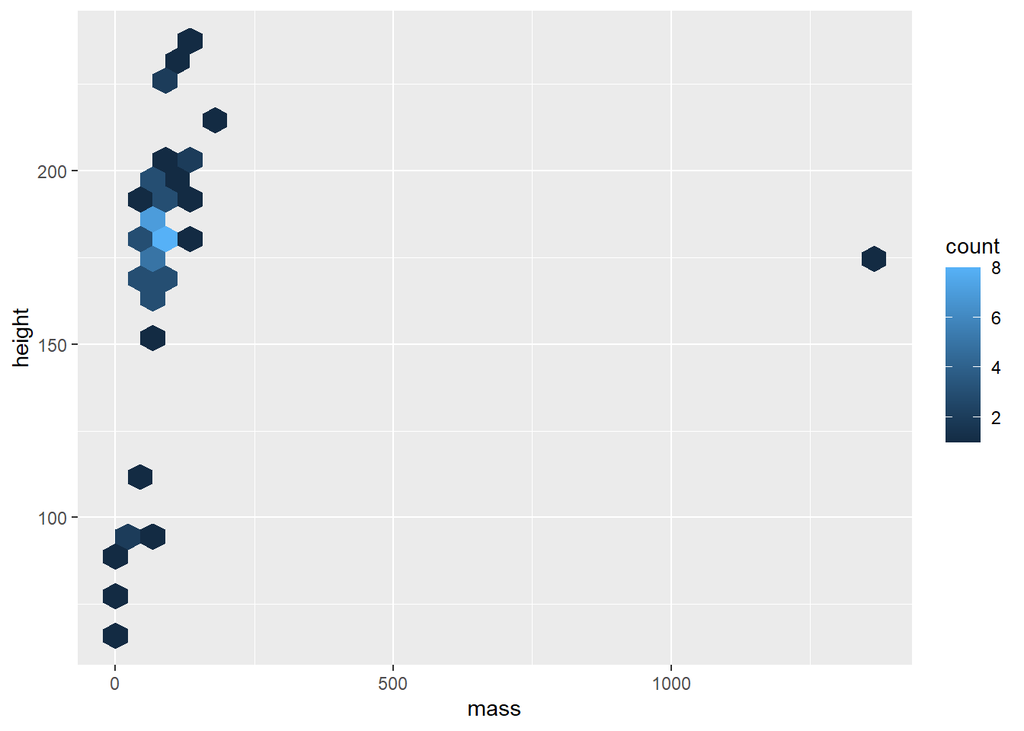

```r
px <- ggplot(sw, aes(x=mass, y=height))
px + geom_hex()
```

**1.6) Add text labels to the points:**

- Add `geom_text()` to the plot in addition to geom_point().
- Modify geom_text() to **only plot label characters with a mass greater than 1000**.
- Modify the **color** and **shape** of geom_point

```r
plot1.6 <- ggplot(sw, aes(x=mass, y=height))+
  geom_point(color = '#537C8E', shape = 18) +
  geom_text(
    data = subset(sw, mass > 1000),
    aes(label = firstname),
    vjust = -0.5, hjust = 0.5) +
  theme_bw()
```

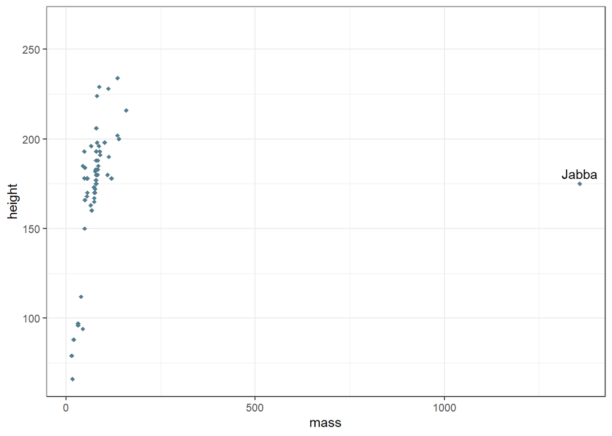

```r
plot1.6
```

**1.7) Plot the distribution of height:**

First use `geom_histogram()` to plot a histogram of the **height**

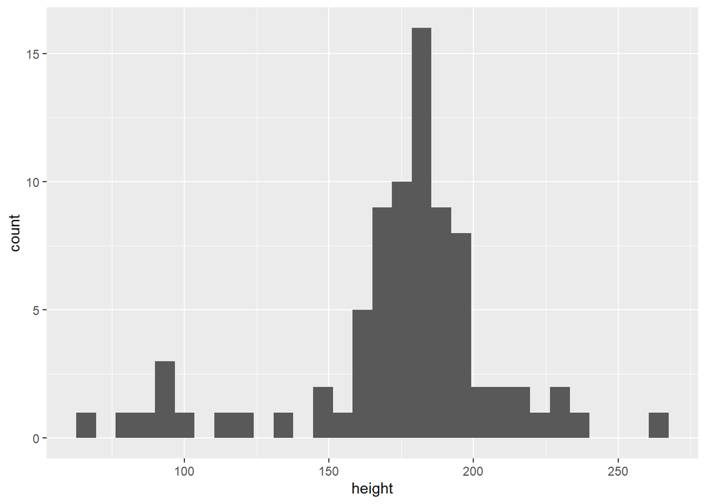

```r
plot1.7_hist <- ggplot(sw, aes(x=height))+
  geom_histogram()
plot1.7_hist
```

Second use `geom_density()`

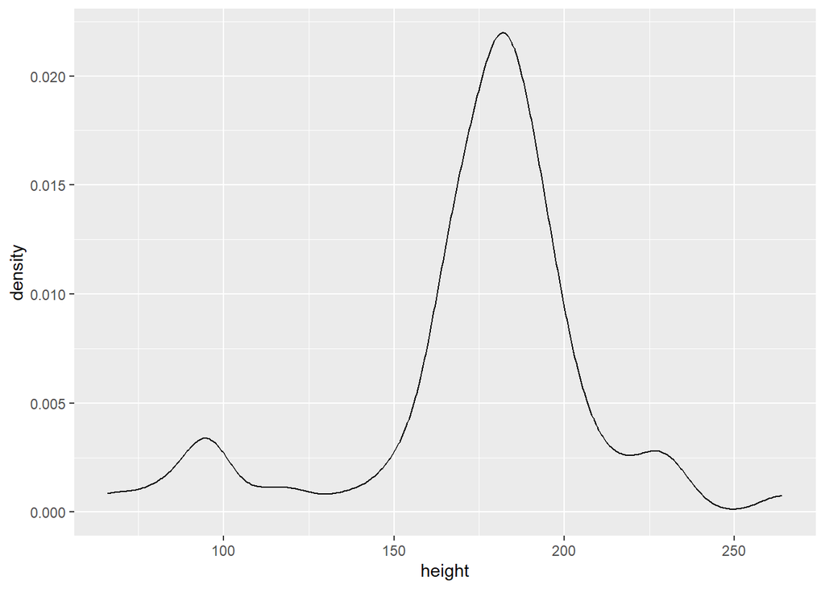

```r
plot1.7_dens <- ggplot(sw, aes(x=height))+
  geom_density()
plot1.7_dens
```

Third use the empirical cumulative distribution function `stat_ecdf()`.

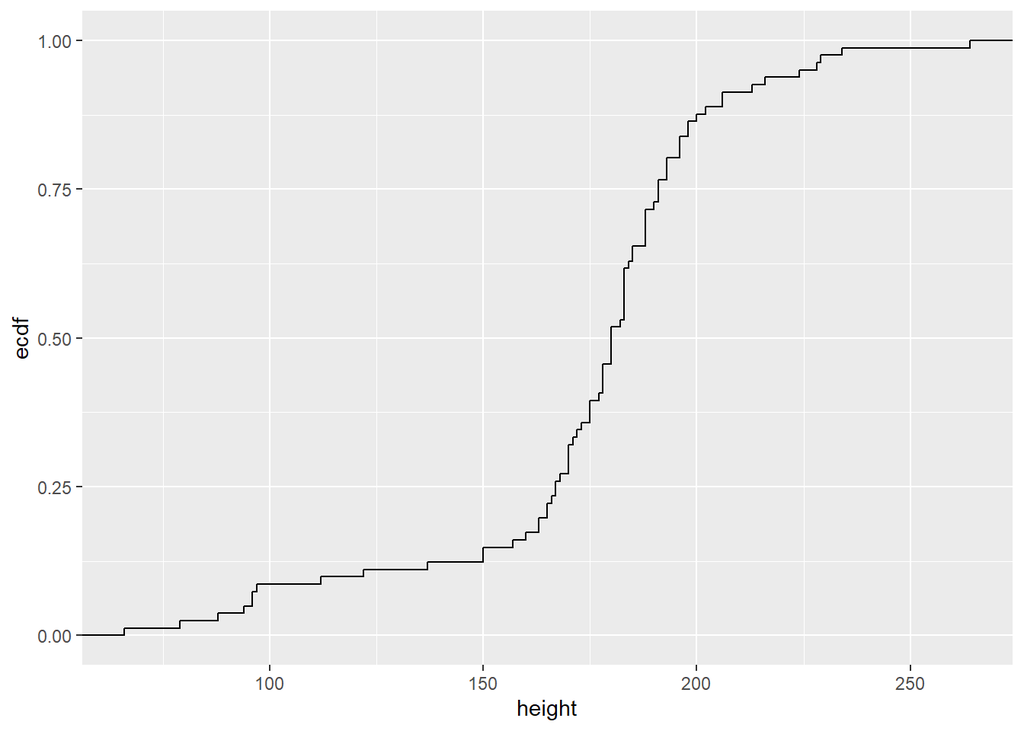

```r
plot1.7_ecdf <- ggplot(sw, aes(x = height)) +
  stat_ecdf()
plot1.7_ecdf
```

Histogram and density plots can be displayed together since they share the same Y-scale…:

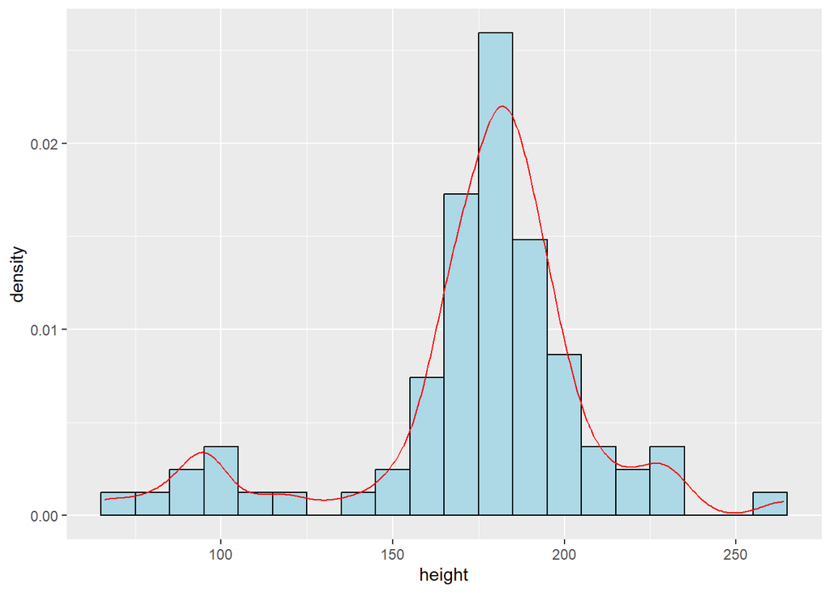

```r
ggplot(sw, aes(x = height)) +
  geom_histogram(aes(y = ..density..), binwidth = 10, fill = "lightblue", color = "black") +
  geom_density(color = "red")
```

.. but ECDF is better displayed in a separate plot

**1.8) Modify the plot to add facets on the columns based on gender using the function `facet_grid()`. Remove the extra white space by change the space and scales parameters.**

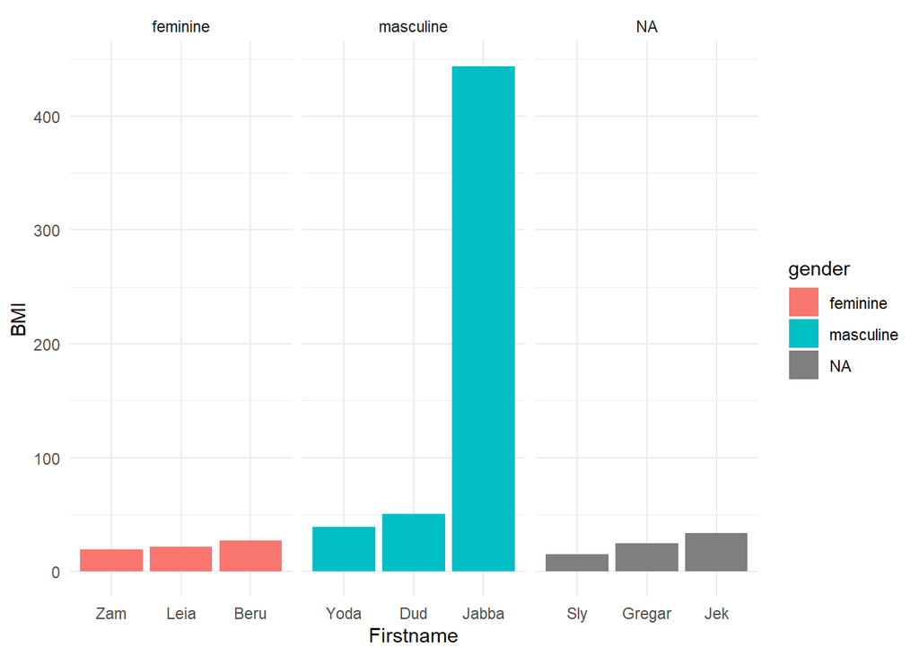

```r
sw |>
  group_by(gender) |>
  slice_max(bmi, n = 3) |>
  ggplot(aes(x=fct_reorder(firstname, bmi), y=bmi, fill=gender)) +
  geom_bar(stat="identity") +
  facet_grid(. ~ gender, scales = "free_x", space = "free") +
  labs(x = "Firstname", y = "BMI") +
  theme_minimal()
```

**Factors**

Factors are **vectors with an order**.

**1.9) Correct the code to show the violin plot with the males in the first violin and the females in the second one.**

If I want the violin plot with **males** first:

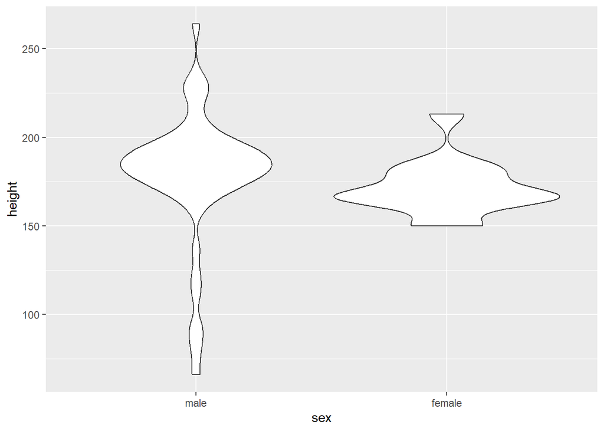

```r
sw |>
  filter(sex %in% c("male", "female")) |>
  mutate(sex = factor(sex, levels = c("male", "female"))) |> # convert vectors to factors and change the order of the levels to male first
  ggplot(aes(x = sex, y = height)) +
  geom_violin()
```

If I want the violin plot with **females** first:

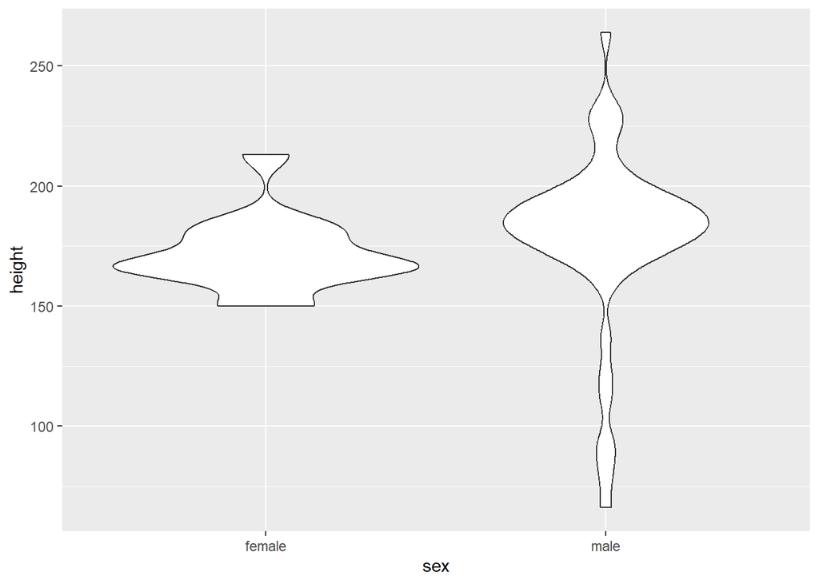

```r
sw |>
  filter(sex %in% c("male", "female")) |>
  mutate(sex = factor(sex, levels = c("female", "male"))) |> # convert vectors to factors and change the order of the levels to male first
  ggplot(aes(x = sex, y = height)) +
  geom_violin()
```

**Downloading data and metadata with GSE148118**

**`Loading packages:`**

```r
require(gemma.R)
require(tidyverse)
```

**1.10) Run the code above for this dataset and then report the identified dataset (number of samples and conditions) you find.**

```r
gse <- "GSE148118"
metadata <- get_dataset_samples(gse) |>
  make_design('text') |>
  select(-factorValues)
```

Download the expression data:

```r
e <- get_dataset_processed_expression(gse)
colnames(e)
```

```
##  [1] "Probe"           "GeneSymbol"      "GeneName"        "NCBIid"
##  [5] "P53ki-2"         "P53ki-3"         "WT-haESC-T3-1-3" "WT-haESC-T3-1-2"
##  [9] "WT-haESC-T3-1-1" "P53ki-1"
```

```r
e <- as.data.frame(e)
```

From the obtained metadata we make a matrix with sample names as columns and gene symbols as rows:

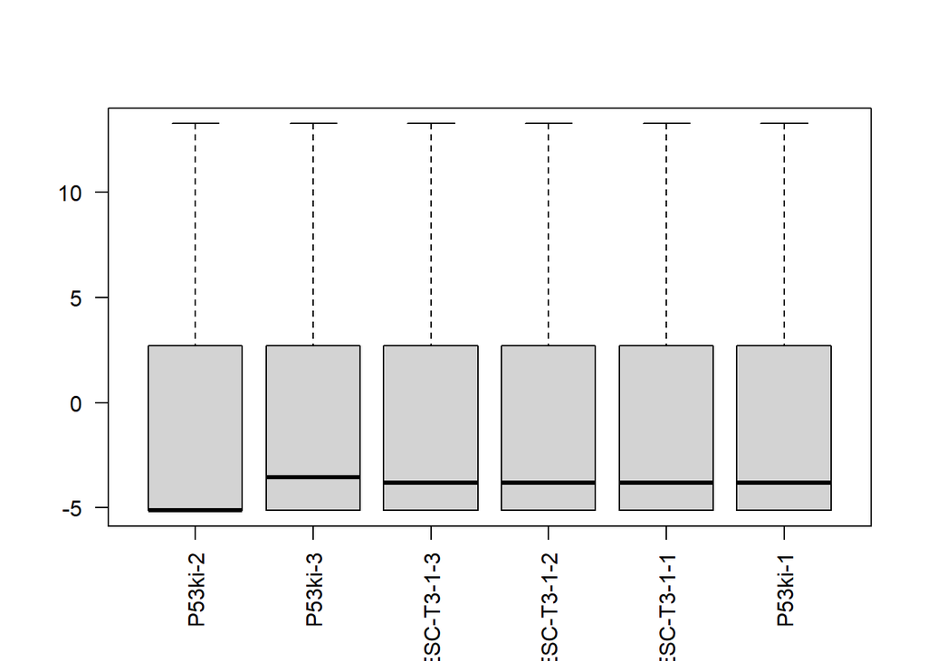

```r
dataMT <- as.matrix(e[,row.names(metadata)])
row.names(dataMT) <- e$GeneSymbol
boxplot(dataMT, las=2)
```

> There are 6 samples in 2 conditions: **Homozygous negative TP53 [human] tumor protein p53** and **wild type genotype**

```r
view(metadata)
```